# SPSS_Output_lesson24

Log  
Log - Log - November 19, 2017

* let's compare the 7 subjects who had missing items  
USE ALL.  
COMPUTE filter_$=(nmiss_cesd > 0).  
VARIABLE LABELS filter_$ 'nmiss_cesd > 0 (FILTER)'.  
VALUE LABELS filter_$ 0 'Not Selected' 1 'Selected'.  
FORMATS filter_$ (f1.0).  
FILTER BY filter_$.  
EXECUTE.  
FREQUENCIES VARIABLES=cesd sum_cesd  
/NTILES=4  
/STATISTICS=STDDEV MINIMUM MAXIMUM MEAN  
/HISTOGRAM  
/ORDER=ANALYSIS.

Frequencies  
Frequencies - Statistics - November 19, 2017

StatisticsStatistics, table, 2 levels of column headers and 1 levels of row headers, table with 10 columns and 5 rows

|  | N |  | Mean | Std. Deviation | Minimum | Maximum | Percentiles |  |  |
| --- | --- | --- | --- | --- | --- | --- | --- | --- | --- |
|  | Valid | Missing |  |  |  |  | 25 | 50 | 75 |
| cesd CESD total score - Baseline | 7 | 0 | 29.57 | 12.830 | 15 | 44 | 17.00 | 29.00 | 44.00 |
| sum_cesd | 7 | 0 | 31.1278 | 13.50568 | 15.79 | 46.32 | 17.8947 | 30.5263 | 46.3158 |

Frequency Table  
Frequency Table - cesd CESD total score - Baseline - November 19, 2017

cesd CESD total score - Baselinecesd CESD total score - Baseline, table, 1 levels of column headers and 2 levels of row headers, table with 6 columns and 9 rows

|  |  | Frequency | Percent | Valid Percent | Cumulative Percent |
| --- | --- | --- | --- | --- | --- |
| Valid | 15 | 1 | 14.3 | 14.3 | 14.3 |
|  | 17 | 1 | 14.3 | 14.3 | 28.6 |
|  | 19 | 1 | 14.3 | 14.3 | 42.9 |
|  | 29 | 1 | 14.3 | 14.3 | 57.1 |
|  | 39 | 1 | 14.3 | 14.3 | 71.4 |
|  | 44 | 2 | 28.6 | 28.6 | 100.0 |
|  | Total | 7 | 100.0 | 100.0 |  |

Frequency Table  
Frequency Table - sum_cesd - November 19, 2017

sum_cesdsum_cesd, table, 1 levels of column headers and 2 levels of row headers, table with 6 columns and 9 rows

|  |  | Frequency | Percent | Valid Percent | Cumulative Percent |
| --- | --- | --- | --- | --- | --- |
| Valid | 15.79 | 1 | 14.3 | 14.3 | 14.3 |
|  | 17.89 | 1 | 14.3 | 14.3 | 28.6 |
|  | 20.00 | 1 | 14.3 | 14.3 | 42.9 |
|  | 30.53 | 1 | 14.3 | 14.3 | 57.1 |
|  | 41.05 | 1 | 14.3 | 14.3 | 71.4 |
|  | 46.32 | 2 | 28.6 | 28.6 | 100.0 |
|  | Total | 7 | 100.0 | 100.0 |  |

Histogram  
Histogram - CESD total score - Baseline - November 19, 2017

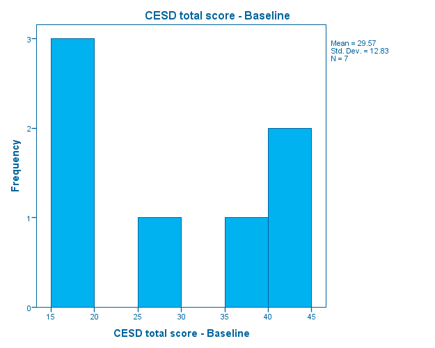

Histogram  
Histogram - sum_cesd - November 19, 2017

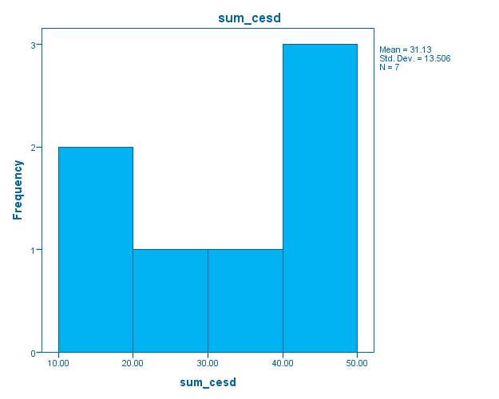

Log  
Log - Log - November 19, 2017

FILTER OFF.  
USE ALL.  
EXECUTE.  
SORT CASES BY nmiss_cesd (D).  
* suppose we did a simple sum without mean substitution  
COMPUTE sum_cesd_simplesum=sum(f1a,f1b,f1c,f1dr,f1e,f1f,f1g,f1hr,f1i,f1j,f1k,f1lr,f1m,f1n,f1o,f1pr,  
f1q,f1r,f1s,f1t).  
EXECUTE.  
* compare the stats again.  
FREQUENCIES VARIABLES=cesd sum_cesd sum_cesd_simplesum  
/NTILES=4  
/STATISTICS=STDDEV MINIMUM MAXIMUM MEAN  
/HISTOGRAM  
/ORDER=ANALYSIS.

Frequencies  
Frequencies - Statistics - November 19, 2017

StatisticsStatistics, table, 2 levels of column headers and 1 levels of row headers, table with 10 columns and 6 rows

|  | N |  | Mean | Std. Deviation | Minimum | Maximum | Percentiles |  |  |
| --- | --- | --- | --- | --- | --- | --- | --- | --- | --- |
|  | Valid | Missing |  |  |  |  | 25 | 50 | 75 |
| cesd CESD total score - Baseline | 453 | 0 | 32.85 | 12.514 | 1 | 60 | 24.50 | 34.00 | 41.00 |
| sum_cesd | 453 | 0 | 32.8717 | 12.51906 | 1.00 | 60.00 | 24.5000 | 34.0000 | 41.0000 |
| sum_cesd_simplesum | 453 | 0 | 32.8477 | 12.51446 | 1.00 | 60.00 | 24.5000 | 34.0000 | 41.0000 |

Frequency Table  
Frequency Table - cesd CESD total score - Baseline - November 19, 2017

cesd CESD total score - Baselinecesd CESD total score - Baseline, table, 1 levels of column headers and 2 levels of row headers, table with 6 columns and 61 rows

|  |  | Frequency | Percent | Valid Percent | Cumulative Percent |
| --- | --- | --- | --- | --- | --- |
| Valid | 1 | 1 | .2 | .2 | .2 |
|  | 3 | 2 | .4 | .4 | .7 |
|  | 4 | 4 | .9 | .9 | 1.5 |
|  | 5 | 1 | .2 | .2 | 1.8 |
|  | 6 | 4 | .9 | .9 | 2.6 |
|  | 7 | 2 | .4 | .4 | 3.1 |
|  | 8 | 3 | .7 | .7 | 3.8 |
|  | 9 | 3 | .7 | .7 | 4.4 |
|  | 10 | 4 | .9 | .9 | 5.3 |
|  | 11 | 5 | 1.1 | 1.1 | 6.4 |
|  | 12 | 4 | .9 | .9 | 7.3 |
|  | 13 | 1 | .2 | .2 | 7.5 |
|  | 14 | 3 | .7 | .7 | 8.2 |
|  | 15 | 9 | 2.0 | 2.0 | 10.2 |
|  | 16 | 7 | 1.5 | 1.5 | 11.7 |
|  | 17 | 8 | 1.8 | 1.8 | 13.5 |
|  | 18 | 7 | 1.5 | 1.5 | 15.0 |
|  | 19 | 8 | 1.8 | 1.8 | 16.8 |
|  | 20 | 4 | .9 | .9 | 17.7 |
|  | 21 | 8 | 1.8 | 1.8 | 19.4 |
|  | 22 | 6 | 1.3 | 1.3 | 20.8 |
|  | 23 | 10 | 2.2 | 2.2 | 23.0 |
|  | 24 | 9 | 2.0 | 2.0 | 24.9 |
|  | 25 | 6 | 1.3 | 1.3 | 26.3 |
|  | 26 | 11 | 2.4 | 2.4 | 28.7 |
|  | 27 | 11 | 2.4 | 2.4 | 31.1 |
|  | 28 | 13 | 2.9 | 2.9 | 34.0 |
|  | 29 | 14 | 3.1 | 3.1 | 37.1 |
|  | 30 | 14 | 3.1 | 3.1 | 40.2 |
|  | 31 | 16 | 3.5 | 3.5 | 43.7 |
|  | 32 | 8 | 1.8 | 1.8 | 45.5 |
|  | 33 | 14 | 3.1 | 3.1 | 48.6 |
|  | 34 | 16 | 3.5 | 3.5 | 52.1 |
|  | 35 | 12 | 2.6 | 2.6 | 54.7 |
|  | 36 | 17 | 3.8 | 3.8 | 58.5 |
|  | 37 | 17 | 3.8 | 3.8 | 62.3 |
|  | 38 | 13 | 2.9 | 2.9 | 65.1 |
|  | 39 | 18 | 4.0 | 4.0 | 69.1 |
|  | 40 | 19 | 4.2 | 4.2 | 73.3 |
|  | 41 | 12 | 2.6 | 2.6 | 75.9 |
|  | 42 | 9 | 2.0 | 2.0 | 77.9 |
|  | 43 | 8 | 1.8 | 1.8 | 79.7 |
|  | 44 | 9 | 2.0 | 2.0 | 81.7 |
|  | 45 | 9 | 2.0 | 2.0 | 83.7 |
|  | 46 | 9 | 2.0 | 2.0 | 85.7 |
|  | 47 | 7 | 1.5 | 1.5 | 87.2 |
|  | 48 | 7 | 1.5 | 1.5 | 88.7 |
|  | 49 | 9 | 2.0 | 2.0 | 90.7 |
|  | 50 | 2 | .4 | .4 | 91.2 |
|  | 51 | 12 | 2.6 | 2.6 | 93.8 |
|  | 52 | 5 | 1.1 | 1.1 | 94.9 |
|  | 53 | 5 | 1.1 | 1.1 | 96.0 |
|  | 54 | 5 | 1.1 | 1.1 | 97.1 |
|  | 55 | 3 | .7 | .7 | 97.8 |
|  | 56 | 3 | .7 | .7 | 98.5 |
|  | 57 | 3 | .7 | .7 | 99.1 |
|  | 58 | 3 | .7 | .7 | 99.8 |
|  | 60 | 1 | .2 | .2 | 100.0 |
|  | Total | 453 | 100.0 | 100.0 |  |

Frequency Table  
Frequency Table - sum_cesd - November 19, 2017

sum_cesdsum_cesd, table, 1 levels of column headers and 2 levels of row headers, table with 6 columns and 66 rows

[output not shown]

Frequency Table  
Frequency Table - sum_cesd_simplesum - November 19, 2017

sum_cesd_simplesumsum_cesd_simplesum, table, 1 levels of column headers and 2 levels of row headers, table with 6 columns and 61 rows

|  |  | Frequency | Percent | Valid Percent | Cumulative Percent |
| --- | --- | --- | --- | --- | --- |
| Valid | 1.00 | 1 | .2 | .2 | .2 |
|  | 3.00 | 2 | .4 | .4 | .7 |
|  | 4.00 | 4 | .9 | .9 | 1.5 |
|  | 5.00 | 1 | .2 | .2 | 1.8 |
|  | 6.00 | 4 | .9 | .9 | 2.6 |
|  | 7.00 | 2 | .4 | .4 | 3.1 |
|  | 8.00 | 3 | .7 | .7 | 3.8 |
|  | 9.00 | 3 | .7 | .7 | 4.4 |
|  | 10.00 | 4 | .9 | .9 | 5.3 |
|  | 11.00 | 5 | 1.1 | 1.1 | 6.4 |
|  | 12.00 | 4 | .9 | .9 | 7.3 |
|  | 13.00 | 1 | .2 | .2 | 7.5 |
|  | 14.00 | 3 | .7 | .7 | 8.2 |
|  | 15.00 | 9 | 2.0 | 2.0 | 10.2 |
|  | 16.00 | 7 | 1.5 | 1.5 | 11.7 |
|  | 17.00 | 8 | 1.8 | 1.8 | 13.5 |
|  | 18.00 | 7 | 1.5 | 1.5 | 15.0 |
|  | 19.00 | 8 | 1.8 | 1.8 | 16.8 |
|  | 20.00 | 4 | .9 | .9 | 17.7 |
|  | 21.00 | 8 | 1.8 | 1.8 | 19.4 |
|  | 22.00 | 6 | 1.3 | 1.3 | 20.8 |
|  | 23.00 | 10 | 2.2 | 2.2 | 23.0 |
|  | 24.00 | 9 | 2.0 | 2.0 | 24.9 |
|  | 25.00 | 6 | 1.3 | 1.3 | 26.3 |
|  | 26.00 | 11 | 2.4 | 2.4 | 28.7 |
|  | 27.00 | 11 | 2.4 | 2.4 | 31.1 |
|  | 28.00 | 13 | 2.9 | 2.9 | 34.0 |
|  | 29.00 | 14 | 3.1 | 3.1 | 37.1 |
|  | 30.00 | 14 | 3.1 | 3.1 | 40.2 |
|  | 31.00 | 16 | 3.5 | 3.5 | 43.7 |
|  | 32.00 | 8 | 1.8 | 1.8 | 45.5 |
|  | 33.00 | 14 | 3.1 | 3.1 | 48.6 |
|  | 34.00 | 16 | 3.5 | 3.5 | 52.1 |
|  | 35.00 | 12 | 2.6 | 2.6 | 54.7 |
|  | 36.00 | 17 | 3.8 | 3.8 | 58.5 |
|  | 37.00 | 17 | 3.8 | 3.8 | 62.3 |
|  | 38.00 | 13 | 2.9 | 2.9 | 65.1 |
|  | 39.00 | 18 | 4.0 | 4.0 | 69.1 |
|  | 40.00 | 19 | 4.2 | 4.2 | 73.3 |
|  | 41.00 | 12 | 2.6 | 2.6 | 75.9 |
|  | 42.00 | 9 | 2.0 | 2.0 | 77.9 |
|  | 43.00 | 8 | 1.8 | 1.8 | 79.7 |
|  | 44.00 | 9 | 2.0 | 2.0 | 81.7 |
|  | 45.00 | 9 | 2.0 | 2.0 | 83.7 |
|  | 46.00 | 9 | 2.0 | 2.0 | 85.7 |
|  | 47.00 | 7 | 1.5 | 1.5 | 87.2 |
|  | 48.00 | 7 | 1.5 | 1.5 | 88.7 |
|  | 49.00 | 9 | 2.0 | 2.0 | 90.7 |
|  | 50.00 | 2 | .4 | .4 | 91.2 |
|  | 51.00 | 12 | 2.6 | 2.6 | 93.8 |
|  | 52.00 | 5 | 1.1 | 1.1 | 94.9 |
|  | 53.00 | 5 | 1.1 | 1.1 | 96.0 |
|  | 54.00 | 5 | 1.1 | 1.1 | 97.1 |
|  | 55.00 | 3 | .7 | .7 | 97.8 |
|  | 56.00 | 3 | .7 | .7 | 98.5 |
|  | 57.00 | 3 | .7 | .7 | 99.1 |
|  | 58.00 | 3 | .7 | .7 | 99.8 |
|  | 60.00 | 1 | .2 | .2 | 100.0 |
|  | Total | 453 | 100.0 | 100.0 |  |

Histogram  
Histogram - CESD total score - Baseline - November 19, 2017

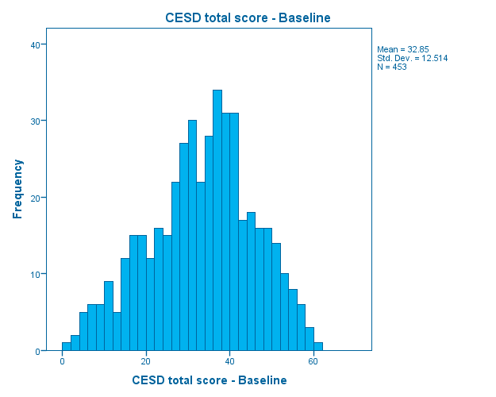

Histogram  
Histogram - sum_cesd - November 19, 2017

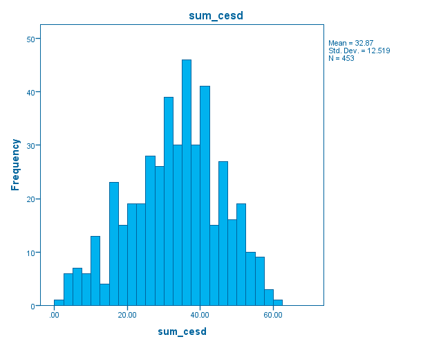

Histogram  
Histogram - sum_cesd_simplesum - November 19, 2017

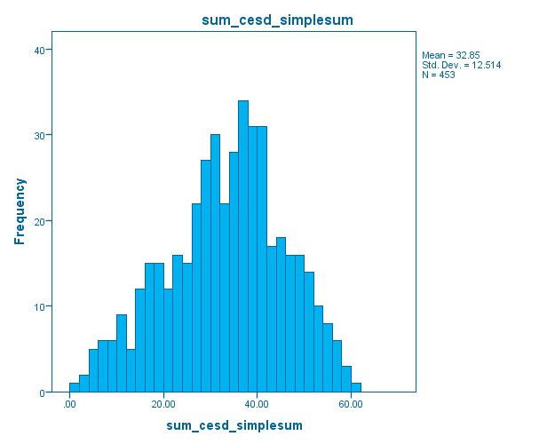

Log  
Log - Log - November 19, 2017

DATASET ACTIVATE DataSet1.  
SAVE OUTFILE='C:\MyGithub\N736Fall2017_lesson24\helpmkh.sav'  
/COMPRESSED.  
* let's compute the realiability - cronbach's alpha  
* take a look at the correlation matrix  
RELIABILITY  
/VARIABLES=f1dr f1hr f1lr f1pr f1a f1b f1c f1e f1f f1g f1i f1j f1k f1m f1n f1o f1q f1r f1s f1t  
/SCALE("Cronabach's alpha for 20 CESD items with items 4,8,12,16 reverse coded") ALL  
/MODEL=ALPHA  
/STATISTICS=DESCRIPTIVE SCALE CORR  
/SUMMARY=TOTAL MEANS VARIANCE COV CORR.

Scale: Cronabach's alpha for 20 CESD items with items 4,8,12,16 reverse coded  
Scale: Cronabach's alpha for 20 CESD items with items 4,8,12,16 reverse coded - Case Processing Summ(more)ary - November 19, 2017(less)

Case Processing SummaryCase Processing Summary, table, 1 levels of column headers and 2 levels of row headers, table with 4 columns and 6 rows

|  |  | N | % |
| --- | --- | --- | --- |
| Cases | Valid | 446 | 98.5 |
|  | Excluded<sup>a</sup> | 7 | 1.5 |
|  | Total | 453 | 100.0 |

a. Listwise deletion based on all variables in the procedure.

Scale: Cronabach's alpha for 20 CESD items with items 4,8,12,16 reverse coded  
Scale: Cronabach's alpha for 20 CESD items with items 4,8,12,16 reverse coded - Reliability Statisti(more)cs - November 19, 2017(less)

Reliability StatisticsReliability Statistics, table, 1 levels of column headers and 0 levels of row headers, table with 3 columns and 3 rows

| Cronbach's Alpha | Cronbach's Alpha Based on Standardized Items | N of Items |
| --- | --- | --- |
| .888 | .889 | 20 |

Scale: Cronabach's alpha for 20 CESD items with items 4,8,12,16 reverse coded  
Scale: Cronabach's alpha for 20 CESD items with items 4,8,12,16 reverse coded - Item Statistics - No(more)vember 19, 2017(less)

Item StatisticsItem Statistics, table, 1 levels of column headers and 1 levels of row headers, table with 4 columns and 22 rows

|  | Mean | Std. Deviation | N |
| --- | --- | --- | --- |
| f1dr Reverse Coded CESD 4 - I felt that I was just as good as other people | 1.44 | 1.191 | 446 |
| f1hr Reverse Coded CESD 8 - I felt hopeful about the future | 1.52 | 1.157 | 446 |
| f1lr Reverse Coded CESD 12 - I was happy | 1.92 | 1.009 | 446 |
| f1pr Reverse Coded CESD 16 - I enjoyed life | 1.67 | 1.132 | 446 |
| f1a CESD 1 - I was bothered by things that usually don't bother me | 1.63 | 1.111 | 446 |
| f1b CESD 2 - I did not feel like eating; my appetite was poor | 1.40 | 1.123 | 446 |
| f1c CESD 3 - I felt that I could not shake off the blues even with help from my family or friends | 1.92 | 1.097 | 446 |
| f1e CESD 5 - I had trouble keeping my mind on what I was doing | 1.68 | 1.093 | 446 |
| f1f CESD 6 - I felt depressed | 2.02 | 1.058 | 446 |
| f1g CESD 7 - I felt that everything I did was an effort | 1.74 | 1.096 | 446 |
| f1i CESD 9 - I thought my life had been a failure | 1.88 | 1.126 | 446 |
| f1j CESD 10 - I felt fearful | 1.52 | 1.162 | 446 |
| f1k CESD 11 - My sleep was restless | 2.03 | 1.115 | 446 |
| f1m CESD 13 - I talked less than usual | 1.50 | 1.076 | 446 |
| f1n CESD 14 - I felt lonely | 2.00 | 1.077 | 446 |
| f1o CESD 15 - People were unfriendly | 1.23 | 1.123 | 446 |
| f1q CESD 17 - I had crying spells | 1.07 | 1.161 | 446 |
| f1r CESD 18 - I felt sad | 1.96 | 1.009 | 446 |
| f1s CESD 19 - I felt that people dislike me | 1.23 | 1.134 | 446 |
| f1t CESD 20 - I could not get going | 1.53 | 1.095 | 446 |

Scale: Cronabach's alpha for 20 CESD items with items 4,8,12,16 reverse coded  
Scale: Cronabach's alpha for 20 CESD items with items 4,8,12,16 reverse coded - Inter-Item Correlati(more)on Matrix - November 19, 2017(less)

Inter-Item Correlation MatrixInter-Item Correlation Matrix, table, 1 levels of column headers and 1 levels of row headers, table with 21 columns and 22 rows

|  | f1dr Reverse Coded CESD 4 - I felt that I was just as good as other people | f1hr Reverse Coded CESD 8 - I felt hopeful about the future | f1lr Reverse Coded CESD 12 - I was happy | f1pr Reverse Coded CESD 16 - I enjoyed life | f1a CESD 1 - I was bothered by things that usually don't bother me | f1b CESD 2 - I did not feel like eating; my appetite was poor | f1c CESD 3 - I felt that I could not shake off the blues even with help from my family or friends | f1e CESD 5 - I had trouble keeping my mind on what I was doing | f1f CESD 6 - I felt depressed | f1g CESD 7 - I felt that everything I did was an effort | f1i CESD 9 - I thought my life had been a failure | f1j CESD 10 - I felt fearful | f1k CESD 11 - My sleep was restless | f1m CESD 13 - I talked less than usual | f1n CESD 14 - I felt lonely | f1o CESD 15 - People were unfriendly | f1q CESD 17 - I had crying spells | f1r CESD 18 - I felt sad | f1s CESD 19 - I felt that people dislike me | f1t CESD 20 - I could not get going |
| --- | --- | --- | --- | --- | --- | --- | --- | --- | --- | --- | --- | --- | --- | --- | --- | --- | --- | --- | --- | --- |
| f1dr Reverse Coded CESD 4 - I felt that I was just as good as other people | 1.000 | .423 | .300 | .345 | .265 | .157 | .368 | .182 | .354 | .090 | .313 | .259 | .164 | .125 | .247 | .104 | .226 | .327 | .258 | .358 |
| f1hr Reverse Coded CESD 8 - I felt hopeful about the future | .423 | 1.000 | .402 | .478 | .207 | .167 | .202 | .190 | .253 | -.005 | .247 | .144 | .172 | .069 | .220 | .111 | .106 | .245 | .186 | .267 |
| f1lr Reverse Coded CESD 12 - I was happy | .300 | .402 | 1.000 | .526 | .242 | .223 | .368 | .209 | .404 | .129 | .348 | .291 | .200 | .095 | .348 | .132 | .162 | .330 | .156 | .305 |
| f1pr Reverse Coded CESD 16 - I enjoyed life | .345 | .478 | .526 | 1.000 | .173 | .232 | .303 | .131 | .330 | .031 | .286 | .245 | .136 | .059 | .324 | .153 | .103 | .296 | .254 | .278 |
| f1a CESD 1 - I was bothered by things that usually don't bother me | .265 | .207 | .242 | .173 | 1.000 | .351 | .400 | .283 | .359 | .193 | .295 | .231 | .305 | .170 | .264 | .208 | .243 | .328 | .236 | .366 |
| f1b CESD 2 - I did not feel like eating; my appetite was poor | .157 | .167 | .223 | .232 | .351 | 1.000 | .346 | .335 | .297 | .223 | .256 | .227 | .394 | .167 | .303 | .201 | .243 | .282 | .233 | .343 |
| f1c CESD 3 - I felt that I could not shake off the blues even with help from my family or friends | .368 | .202 | .368 | .303 | .400 | .346 | 1.000 | .402 | .553 | .313 | .433 | .425 | .357 | .221 | .444 | .307 | .326 | .500 | .373 | .455 |
| f1e CESD 5 - I had trouble keeping my mind on what I was doing | .182 | .190 | .209 | .131 | .283 | .335 | .402 | 1.000 | .408 | .278 | .287 | .299 | .325 | .213 | .221 | .222 | .289 | .325 | .242 | .396 |
| f1f CESD 6 - I felt depressed | .354 | .253 | .404 | .330 | .359 | .297 | .553 | .408 | 1.000 | .384 | .468 | .447 | .371 | .201 | .444 | .282 | .350 | .576 | .336 | .477 |
| f1g CESD 7 - I felt that everything I did was an effort | .090 | -.005 | .129 | .031 | .193 | .223 | .313 | .278 | .384 | 1.000 | .208 | .189 | .259 | .137 | .169 | .201 | .176 | .296 | .199 | .312 |
| f1i CESD 9 - I thought my life had been a failure | .313 | .247 | .348 | .286 | .295 | .256 | .433 | .287 | .468 | .208 | 1.000 | .521 | .243 | .167 | .408 | .292 | .266 | .421 | .357 | .424 |
| f1j CESD 10 - I felt fearful | .259 | .144 | .291 | .245 | .231 | .227 | .425 | .299 | .447 | .189 | .521 | 1.000 | .334 | .171 | .400 | .306 | .367 | .449 | .371 | .382 |
| f1k CESD 11 - My sleep was restless | .164 | .172 | .200 | .136 | .305 | .394 | .357 | .325 | .371 | .259 | .243 | .334 | 1.000 | .170 | .324 | .193 | .260 | .365 | .216 | .318 |
| f1m CESD 13 - I talked less than usual | .125 | .069 | .095 | .059 | .170 | .167 | .221 | .213 | .201 | .137 | .167 | .171 | .170 | 1.000 | .293 | .211 | .122 | .255 | .225 | .212 |
| f1n CESD 14 - I felt lonely | .247 | .220 | .348 | .324 | .264 | .303 | .444 | .221 | .444 | .169 | .408 | .400 | .324 | .293 | 1.000 | .213 | .280 | .552 | .319 | .335 |
| f1o CESD 15 - People were unfriendly | .104 | .111 | .132 | .153 | .208 | .201 | .307 | .222 | .282 | .201 | .292 | .306 | .193 | .211 | .213 | 1.000 | .246 | .285 | .500 | .394 |
| f1q CESD 17 - I had crying spells | .226 | .106 | .162 | .103 | .243 | .243 | .326 | .289 | .350 | .176 | .266 | .367 | .260 | .122 | .280 | .246 | 1.000 | .502 | .337 | .331 |
| f1r CESD 18 - I felt sad | .327 | .245 | .330 | .296 | .328 | .282 | .500 | .325 | .576 | .296 | .421 | .449 | .365 | .255 | .552 | .285 | .502 | 1.000 | .419 | .453 |
| f1s CESD 19 - I felt that people dislike me | .258 | .186 | .156 | .254 | .236 | .233 | .373 | .242 | .336 | .199 | .357 | .371 | .216 | .225 | .319 | .500 | .337 | .419 | 1.000 | .481 |
| f1t CESD 20 - I could not get going | .358 | .267 | .305 | .278 | .366 | .343 | .455 | .396 | .477 | .312 | .424 | .382 | .318 | .212 | .335 | .394 | .331 | .453 | .481 | 1.000 |

Scale: Cronabach's alpha for 20 CESD items with items 4,8,12,16 reverse coded  
Scale: Cronabach's alpha for 20 CESD items with items 4,8,12,16 reverse coded - Summary Item Statist(more)ics - November 19, 2017(less)

Summary Item StatisticsSummary Item Statistics, table, 1 levels of column headers and 1 levels of row headers, table with 8 columns and 6 rows

|  | Mean | Minimum | Maximum | Range | Maximum / Minimum | Variance | N of Items |
| --- | --- | --- | --- | --- | --- | --- | --- |
| Item Means | 1.645 | 1.072 | 2.031 | .960 | 1.895 | .083 | 20 |
| Item Variances | 1.228 | 1.018 | 1.420 | .401 | 1.394 | .011 | 20 |
| Inter-Item Covariances | .348 | -.007 | .682 | .688 | -98.160 | .017 | 20 |
| Inter-Item Correlations | .285 | -.005 | .576 | .581 | -105.099 | .012 | 20 |

Scale: Cronabach's alpha for 20 CESD items with items 4,8,12,16 reverse coded  
Scale: Cronabach's alpha for 20 CESD items with items 4,8,12,16 reverse coded - Item-Total Statistic(more)s - November 19, 2017(less)

Item-Total StatisticsItem-Total Statistics, table, 1 levels of column headers and 1 levels of row headers, table with 6 columns and 22 rows

|  | Scale Mean if Item Deleted | Scale Variance if Item Deleted | Corrected Item-Total Correlation | Squared Multiple Correlation | Cronbach's Alpha if Item Deleted |
| --- | --- | --- | --- | --- | --- |
| f1dr Reverse Coded CESD 4 - I felt that I was just as good as other people | 31.46 | 142.492 | .449 | .325 | .884 |
| f1hr Reverse Coded CESD 8 - I felt hopeful about the future | 31.37 | 144.922 | .374 | .356 | .886 |
| f1lr Reverse Coded CESD 12 - I was happy | 30.98 | 144.069 | .479 | .393 | .883 |
| f1pr Reverse Coded CESD 16 - I enjoyed life | 31.23 | 143.722 | .430 | .419 | .885 |
| f1a CESD 1 - I was bothered by things that usually don't bother me | 31.26 | 142.887 | .473 | .269 | .883 |
| f1b CESD 2 - I did not feel like eating; my appetite was poor | 31.50 | 143.091 | .459 | .292 | .884 |
| f1c CESD 3 - I felt that I could not shake off the blues even with help from my family or friends | 30.98 | 138.312 | .666 | .480 | .877 |
| f1e CESD 5 - I had trouble keeping my mind on what I was doing | 31.22 | 142.846 | .484 | .307 | .883 |
| f1f CESD 6 - I felt depressed | 30.88 | 138.509 | .685 | .528 | .877 |
| f1g CESD 7 - I felt that everything I did was an effort | 31.16 | 146.380 | .343 | .230 | .887 |
| f1i CESD 9 - I thought my life had been a failure | 31.02 | 139.917 | .582 | .408 | .880 |
| f1j CESD 10 - I felt fearful | 31.37 | 139.839 | .564 | .412 | .880 |
| f1k CESD 11 - My sleep was restless | 30.87 | 142.888 | .471 | .297 | .883 |
| f1m CESD 13 - I talked less than usual | 31.40 | 147.732 | .298 | .143 | .888 |
| f1n CESD 14 - I felt lonely | 30.89 | 141.020 | .567 | .422 | .880 |
| f1o CESD 15 - People were unfriendly | 31.67 | 144.101 | .420 | .313 | .885 |
| f1q CESD 17 - I had crying spells | 31.83 | 142.732 | .454 | .320 | .884 |
| f1r CESD 18 - I felt sad | 30.94 | 139.514 | .678 | .552 | .877 |
| f1s CESD 19 - I felt that people dislike me | 31.67 | 141.102 | .530 | .416 | .881 |
| f1t CESD 20 - I could not get going | 31.37 | 138.800 | .647 | .457 | .878 |

Scale: Cronabach's alpha for 20 CESD items with items 4,8,12,16 reverse coded  
Scale: Cronabach's alpha for 20 CESD items with items 4,8,12,16 reverse coded - Scale Statistics - N(more)ovember 19, 2017(less)

Scale StatisticsScale Statistics, table, 1 levels of column headers and 0 levels of row headers, table with 4 columns and 3 rows

| Mean | Variance | Std. Deviation | N of Items |
| --- | --- | --- | --- |
| 32.90 | 156.684 | 12.517 | 20 |

Log  
Log - Log - November 19, 2017

* good internal consistency is given by alpha > 0.7, closer to 1 is better.  
* when reviewing the correlation matrix - ideally you do not want any negative  
* correlations and most should be > 0.3.  
* when looking at the item-total stats for leave-one-out  
* none should be better than the alpha computed above.  
* let's run a factor analysis - with the 4 reverse coded items.  
* use PCA, no rotation, keep 2 factors - easier for plotting.  
FACTOR  
/VARIABLES f1a f1b f1c f1e f1f f1g f1i f1j f1k f1m f1n f1o f1q f1r f1s f1t f1dr f1hr f1lr f1pr  
/MISSING LISTWISE  
/ANALYSIS f1a f1b f1c f1e f1f f1g f1i f1j f1k f1m f1n f1o f1q f1r f1s f1t f1dr f1hr f1lr f1pr  
/PRINT UNIVARIATE INITIAL CORRELATION SIG DET KMO EXTRACTION FSCORE  
/PLOT EIGEN ROTATION  
/CRITERIA FACTORS(2) ITERATE(25)  
/EXTRACTION PC  
/ROTATION NOROTATE  
/METHOD=CORRELATION.

Factor Analysis  
Factor Analysis - Descriptive Statistics - November 19, 2017

Descriptive StatisticsDescriptive Statistics, table, 1 levels of column headers and 1 levels of row headers, table with 4 columns and 22 rows

|  | Mean | Std. Deviation | Analysis N |
| --- | --- | --- | --- |
| f1a CESD 1 - I was bothered by things that usually don't bother me | 1.63 | 1.111 | 446 |
| f1b CESD 2 - I did not feel like eating; my appetite was poor | 1.40 | 1.123 | 446 |
| f1c CESD 3 - I felt that I could not shake off the blues even with help from my family or friends | 1.92 | 1.097 | 446 |
| f1e CESD 5 - I had trouble keeping my mind on what I was doing | 1.68 | 1.093 | 446 |
| f1f CESD 6 - I felt depressed | 2.02 | 1.058 | 446 |
| f1g CESD 7 - I felt that everything I did was an effort | 1.74 | 1.096 | 446 |
| f1i CESD 9 - I thought my life had been a failure | 1.88 | 1.126 | 446 |
| f1j CESD 10 - I felt fearful | 1.52 | 1.162 | 446 |
| f1k CESD 11 - My sleep was restless | 2.03 | 1.115 | 446 |
| f1m CESD 13 - I talked less than usual | 1.50 | 1.076 | 446 |
| f1n CESD 14 - I felt lonely | 2.00 | 1.077 | 446 |
| f1o CESD 15 - People were unfriendly | 1.23 | 1.123 | 446 |
| f1q CESD 17 - I had crying spells | 1.07 | 1.161 | 446 |
| f1r CESD 18 - I felt sad | 1.96 | 1.009 | 446 |
| f1s CESD 19 - I felt that people dislike me | 1.23 | 1.134 | 446 |
| f1t CESD 20 - I could not get going | 1.53 | 1.095 | 446 |
| f1dr Reverse Coded CESD 4 - I felt that I was just as good as other people | 1.44 | 1.191 | 446 |
| f1hr Reverse Coded CESD 8 - I felt hopeful about the future | 1.52 | 1.157 | 446 |
| f1lr Reverse Coded CESD 12 - I was happy | 1.92 | 1.009 | 446 |
| f1pr Reverse Coded CESD 16 - I enjoyed life | 1.67 | 1.132 | 446 |

Factor Analysis  
Factor Analysis - Correlation Matrix - November 19, 2017

Correlation Matrix<sup>a</sup>Correlation Matrix, table, 1 levels of column headers and 2 levels of row headers, table with 22 columns and 43 rows

|  |  | f1a CESD 1 - I was bothered by things that usually don't bother me | f1b CESD 2 - I did not feel like eating; my appetite was poor | f1c CESD 3 - I felt that I could not shake off the blues even with help from my family or friends | f1e CESD 5 - I had trouble keeping my mind on what I was doing | f1f CESD 6 - I felt depressed | f1g CESD 7 - I felt that everything I did was an effort | f1i CESD 9 - I thought my life had been a failure | f1j CESD 10 - I felt fearful | f1k CESD 11 - My sleep was restless | f1m CESD 13 - I talked less than usual | f1n CESD 14 - I felt lonely | f1o CESD 15 - People were unfriendly | f1q CESD 17 - I had crying spells | f1r CESD 18 - I felt sad | f1s CESD 19 - I felt that people dislike me | f1t CESD 20 - I could not get going | f1dr Reverse Coded CESD 4 - I felt that I was just as good as other people | f1hr Reverse Coded CESD 8 - I felt hopeful about the future | f1lr Reverse Coded CESD 12 - I was happy | f1pr Reverse Coded CESD 16 - I enjoyed life |
| --- | --- | --- | --- | --- | --- | --- | --- | --- | --- | --- | --- | --- | --- | --- | --- | --- | --- | --- | --- | --- | --- |
| Correlation | f1a CESD 1 - I was bothered by things that usually don't bother me | 1.000 | .351 | .400 | .283 | .359 | .193 | .295 | .231 | .305 | .170 | .264 | .208 | .243 | .328 | .236 | .366 | .265 | .207 | .242 | .173 |
|  | f1b CESD 2 - I did not feel like eating; my appetite was poor | .351 | 1.000 | .346 | .335 | .297 | .223 | .256 | .227 | .394 | .167 | .303 | .201 | .243 | .282 | .233 | .343 | .157 | .167 | .223 | .232 |
|  | f1c CESD 3 - I felt that I could not shake off the blues even with help from my family or friends | .400 | .346 | 1.000 | .402 | .553 | .313 | .433 | .425 | .357 | .221 | .444 | .307 | .326 | .500 | .373 | .455 | .368 | .202 | .368 | .303 |
|  | f1e CESD 5 - I had trouble keeping my mind on what I was doing | .283 | .335 | .402 | 1.000 | .408 | .278 | .287 | .299 | .325 | .213 | .221 | .222 | .289 | .325 | .242 | .396 | .182 | .190 | .209 | .131 |
|  | f1f CESD 6 - I felt depressed | .359 | .297 | .553 | .408 | 1.000 | .384 | .468 | .447 | .371 | .201 | .444 | .282 | .350 | .576 | .336 | .477 | .354 | .253 | .404 | .330 |
|  | f1g CESD 7 - I felt that everything I did was an effort | .193 | .223 | .313 | .278 | .384 | 1.000 | .208 | .189 | .259 | .137 | .169 | .201 | .176 | .296 | .199 | .312 | .090 | -.005 | .129 | .031 |
|  | f1i CESD 9 - I thought my life had been a failure | .295 | .256 | .433 | .287 | .468 | .208 | 1.000 | .521 | .243 | .167 | .408 | .292 | .266 | .421 | .357 | .424 | .313 | .247 | .348 | .286 |
|  | f1j CESD 10 - I felt fearful | .231 | .227 | .425 | .299 | .447 | .189 | .521 | 1.000 | .334 | .171 | .400 | .306 | .367 | .449 | .371 | .382 | .259 | .144 | .291 | .245 |
|  | f1k CESD 11 - My sleep was restless | .305 | .394 | .357 | .325 | .371 | .259 | .243 | .334 | 1.000 | .170 | .324 | .193 | .260 | .365 | .216 | .318 | .164 | .172 | .200 | .136 |
|  | f1m CESD 13 - I talked less than usual | .170 | .167 | .221 | .213 | .201 | .137 | .167 | .171 | .170 | 1.000 | .293 | .211 | .122 | .255 | .225 | .212 | .125 | .069 | .095 | .059 |
|  | f1n CESD 14 - I felt lonely | .264 | .303 | .444 | .221 | .444 | .169 | .408 | .400 | .324 | .293 | 1.000 | .213 | .280 | .552 | .319 | .335 | .247 | .220 | .348 | .324 |
|  | f1o CESD 15 - People were unfriendly | .208 | .201 | .307 | .222 | .282 | .201 | .292 | .306 | .193 | .211 | .213 | 1.000 | .246 | .285 | .500 | .394 | .104 | .111 | .132 | .153 |
|  | f1q CESD 17 - I had crying spells | .243 | .243 | .326 | .289 | .350 | .176 | .266 | .367 | .260 | .122 | .280 | .246 | 1.000 | .502 | .337 | .331 | .226 | .106 | .162 | .103 |
|  | f1r CESD 18 - I felt sad | .328 | .282 | .500 | .325 | .576 | .296 | .421 | .449 | .365 | .255 | .552 | .285 | .502 | 1.000 | .419 | .453 | .327 | .245 | .330 | .296 |
|  | f1s CESD 19 - I felt that people dislike me | .236 | .233 | .373 | .242 | .336 | .199 | .357 | .371 | .216 | .225 | .319 | .500 | .337 | .419 | 1.000 | .481 | .258 | .186 | .156 | .254 |
|  | f1t CESD 20 - I could not get going | .366 | .343 | .455 | .396 | .477 | .312 | .424 | .382 | .318 | .212 | .335 | .394 | .331 | .453 | .481 | 1.000 | .358 | .267 | .305 | .278 |
|  | f1dr Reverse Coded CESD 4 - I felt that I was just as good as other people | .265 | .157 | .368 | .182 | .354 | .090 | .313 | .259 | .164 | .125 | .247 | .104 | .226 | .327 | .258 | .358 | 1.000 | .423 | .300 | .345 |
|  | f1hr Reverse Coded CESD 8 - I felt hopeful about the future | .207 | .167 | .202 | .190 | .253 | -.005 | .247 | .144 | .172 | .069 | .220 | .111 | .106 | .245 | .186 | .267 | .423 | 1.000 | .402 | .478 |
|  | f1lr Reverse Coded CESD 12 - I was happy | .242 | .223 | .368 | .209 | .404 | .129 | .348 | .291 | .200 | .095 | .348 | .132 | .162 | .330 | .156 | .305 | .300 | .402 | 1.000 | .526 |
|  | f1pr Reverse Coded CESD 16 - I enjoyed life | .173 | .232 | .303 | .131 | .330 | .031 | .286 | .245 | .136 | .059 | .324 | .153 | .103 | .296 | .254 | .278 | .345 | .478 | .526 | 1.000 |
| Sig. (1-tailed) | f1a CESD 1 - I was bothered by things that usually don't bother me |  | .000 | .000 | .000 | .000 | .000 | .000 | .000 | .000 | .000 | .000 | .000 | .000 | .000 | .000 | .000 | .000 | .000 | .000 | .000 |
|  | f1b CESD 2 - I did not feel like eating; my appetite was poor | .000 |  | .000 | .000 | .000 | .000 | .000 | .000 | .000 | .000 | .000 | .000 | .000 | .000 | .000 | .000 | .000 | .000 | .000 | .000 |
|  | f1c CESD 3 - I felt that I could not shake off the blues even with help from my family or friends | .000 | .000 |  | .000 | .000 | .000 | .000 | .000 | .000 | .000 | .000 | .000 | .000 | .000 | .000 | .000 | .000 | .000 | .000 | .000 |
|  | f1e CESD 5 - I had trouble keeping my mind on what I was doing | .000 | .000 | .000 |  | .000 | .000 | .000 | .000 | .000 | .000 | .000 | .000 | .000 | .000 | .000 | .000 | .000 | .000 | .000 | .003 |
|  | f1f CESD 6 - I felt depressed | .000 | .000 | .000 | .000 |  | .000 | .000 | .000 | .000 | .000 | .000 | .000 | .000 | .000 | .000 | .000 | .000 | .000 | .000 | .000 |
|  | f1g CESD 7 - I felt that everything I did was an effort | .000 | .000 | .000 | .000 | .000 |  | .000 | .000 | .000 | .002 | .000 | .000 | .000 | .000 | .000 | .000 | .028 | .454 | .003 | .254 |
|  | f1i CESD 9 - I thought my life had been a failure | .000 | .000 | .000 | .000 | .000 | .000 |  | .000 | .000 | .000 | .000 | .000 | .000 | .000 | .000 | .000 | .000 | .000 | .000 | .000 |
|  | f1j CESD 10 - I felt fearful | .000 | .000 | .000 | .000 | .000 | .000 | .000 |  | .000 | .000 | .000 | .000 | .000 | .000 | .000 | .000 | .000 | .001 | .000 | .000 |
|  | f1k CESD 11 - My sleep was restless | .000 | .000 | .000 | .000 | .000 | .000 | .000 | .000 |  | .000 | .000 | .000 | .000 | .000 | .000 | .000 | .000 | .000 | .000 | .002 |
|  | f1m CESD 13 - I talked less than usual | .000 | .000 | .000 | .000 | .000 | .002 | .000 | .000 | .000 |  | .000 | .000 | .005 | .000 | .000 | .000 | .004 | .074 | .022 | .107 |
|  | f1n CESD 14 - I felt lonely | .000 | .000 | .000 | .000 | .000 | .000 | .000 | .000 | .000 | .000 |  | .000 | .000 | .000 | .000 | .000 | .000 | .000 | .000 | .000 |
|  | f1o CESD 15 - People were unfriendly | .000 | .000 | .000 | .000 | .000 | .000 | .000 | .000 | .000 | .000 | .000 |  | .000 | .000 | .000 | .000 | .014 | .010 | .003 | .001 |
|  | f1q CESD 17 - I had crying spells | .000 | .000 | .000 | .000 | .000 | .000 | .000 | .000 | .000 | .005 | .000 | .000 |  | .000 | .000 | .000 | .000 | .013 | .000 | .014 |
|  | f1r CESD 18 - I felt sad | .000 | .000 | .000 | .000 | .000 | .000 | .000 | .000 | .000 | .000 | .000 | .000 | .000 |  | .000 | .000 | .000 | .000 | .000 | .000 |
|  | f1s CESD 19 - I felt that people dislike me | .000 | .000 | .000 | .000 | .000 | .000 | .000 | .000 | .000 | .000 | .000 | .000 | .000 | .000 |  | .000 | .000 | .000 | .000 | .000 |
|  | f1t CESD 20 - I could not get going | .000 | .000 | .000 | .000 | .000 | .000 | .000 | .000 | .000 | .000 | .000 | .000 | .000 | .000 | .000 |  | .000 | .000 | .000 | .000 |
|  | f1dr Reverse Coded CESD 4 - I felt that I was just as good as other people | .000 | .000 | .000 | .000 | .000 | .028 | .000 | .000 | .000 | .004 | .000 | .014 | .000 | .000 | .000 | .000 |  | .000 | .000 | .000 |
|  | f1hr Reverse Coded CESD 8 - I felt hopeful about the future | .000 | .000 | .000 | .000 | .000 | .454 | .000 | .001 | .000 | .074 | .000 | .010 | .013 | .000 | .000 | .000 | .000 |  | .000 | .000 |
|  | f1lr Reverse Coded CESD 12 - I was happy | .000 | .000 | .000 | .000 | .000 | .003 | .000 | .000 | .000 | .022 | .000 | .003 | .000 | .000 | .000 | .000 | .000 | .000 |  | .000 |
|  | f1pr Reverse Coded CESD 16 - I enjoyed life | .000 | .000 | .000 | .003 | .000 | .254 | .000 | .000 | .002 | .107 | .000 | .001 | .014 | .000 | .000 | .000 | .000 | .000 | .000 |  |

a. Determinant = .001

Factor Analysis  
Factor Analysis - KMO and Bartlett's Test - November 19, 2017

KMO and Bartlett's TestKMO and Bartlett's Test, table, 0 levels of column headers and 2 levels of row headers, table with 3 columns and 5 rows

| Kaiser-Meyer-Olkin Measure of Sampling Adequacy. |  | .915 |
| --- | --- | --- |
| Bartlett's Test of Sphericity | Approx. Chi-Square | 2874.072 |
|  | df | 190 |
|  | Sig. | .000 |

Factor Analysis  
Factor Analysis - Communalities - November 19, 2017

CommunalitiesCommunalities, table, 1 levels of column headers and 1 levels of row headers, table with 3 columns and 23 rows

|  | Initial | Extraction |
| --- | --- | --- |
| f1a CESD 1 - I was bothered by things that usually don't bother me | 1.000 | .288 |
| f1b CESD 2 - I did not feel like eating; my appetite was poor | 1.000 | .280 |
| f1c CESD 3 - I felt that I could not shake off the blues even with help from my family or friends | 1.000 | .535 |
| f1e CESD 5 - I had trouble keeping my mind on what I was doing | 1.000 | .344 |
| f1f CESD 6 - I felt depressed | 1.000 | .561 |
| f1g CESD 7 - I felt that everything I did was an effort | 1.000 | .312 |
| f1i CESD 9 - I thought my life had been a failure | 1.000 | .428 |
| f1j CESD 10 - I felt fearful | 1.000 | .414 |
| f1k CESD 11 - My sleep was restless | 1.000 | .325 |
| f1m CESD 13 - I talked less than usual | 1.000 | .170 |
| f1n CESD 14 - I felt lonely | 1.000 | .409 |
| f1o CESD 15 - People were unfriendly | 1.000 | .307 |
| f1q CESD 17 - I had crying spells | 1.000 | .334 |
| f1r CESD 18 - I felt sad | 1.000 | .555 |
| f1s CESD 19 - I felt that people dislike me | 1.000 | .378 |
| f1t CESD 20 - I could not get going | 1.000 | .502 |
| f1dr Reverse Coded CESD 4 - I felt that I was just as good as other people | 1.000 | .420 |
| f1hr Reverse Coded CESD 8 - I felt hopeful about the future | 1.000 | .573 |
| f1lr Reverse Coded CESD 12 - I was happy | 1.000 | .547 |
| f1pr Reverse Coded CESD 16 - I enjoyed life | 1.000 | .630 |

Extraction Method: Principal Component Analysis.

Factor Analysis  
Factor Analysis - Total Variance Explained - November 19, 2017

Total Variance ExplainedTotal Variance Explained, table, 2 levels of column headers and 1 levels of row headers, table with 7 columns and 24 rows

| Component | Initial Eigenvalues |  |  | Extraction Sums of Squared Loadings |  |  |
| --- | --- | --- | --- | --- | --- | --- |
|  | Total | % of Variance | Cumulative % | Total | % of Variance | Cumulative % |
| 1 | 6.635 | 33.176 | 33.176 | 6.635 | 33.176 | 33.176 |
| 2 | 1.677 | 8.385 | 41.561 | 1.677 | 8.385 | 41.561 |
| 3 | 1.177 | 5.884 | 47.445 |  |  |  |
| 4 | 1.010 | 5.048 | 52.493 |  |  |  |
| 5 | .952 | 4.760 | 57.253 |  |  |  |
| 6 | .886 | 4.429 | 61.682 |  |  |  |
| 7 | .855 | 4.275 | 65.957 |  |  |  |
| 8 | .757 | 3.786 | 69.743 |  |  |  |
| 9 | .736 | 3.682 | 73.426 |  |  |  |
| 10 | .674 | 3.368 | 76.793 |  |  |  |
| 11 | .611 | 3.053 | 79.847 |  |  |  |
| 12 | .568 | 2.840 | 82.686 |  |  |  |
| 13 | .546 | 2.732 | 85.418 |  |  |  |
| 14 | .494 | 2.470 | 87.887 |  |  |  |
| 15 | .470 | 2.351 | 90.238 |  |  |  |
| 16 | .430 | 2.151 | 92.389 |  |  |  |
| 17 | .421 | 2.103 | 94.492 |  |  |  |
| 18 | .389 | 1.946 | 96.438 |  |  |  |
| 19 | .377 | 1.884 | 98.322 |  |  |  |
| 20 | .336 | 1.678 | 100.000 |  |  |  |

Extraction Method: Principal Component Analysis.

Factor Analysis  
Factor Analysis - Scree Plot - November 19, 2017

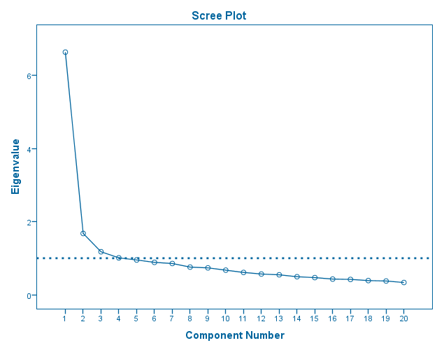

Factor Analysis  
Factor Analysis - Component Matrix - November 19, 2017

Component Matrix<sup>a</sup>Component Matrix, table, 2 levels of column headers and 1 levels of row headers, table with 3 columns and 25 rows

|  | Component |  |
| --- | --- | --- |
|  | 1 | 2 |
| f1a CESD 1 - I was bothered by things that usually don't bother me | .535 | -.049 |
| f1b CESD 2 - I did not feel like eating; my appetite was poor | .516 | -.116 |
| f1c CESD 3 - I felt that I could not shake off the blues even with help from my family or friends | .729 | -.052 |
| f1e CESD 5 - I had trouble keeping my mind on what I was doing | .546 | -.214 |
| f1f CESD 6 - I felt depressed | .749 | -.018 |
| f1g CESD 7 - I felt that everything I did was an effort | .410 | -.379 |
| f1i CESD 9 - I thought my life had been a failure | .652 | .057 |
| f1j CESD 10 - I felt fearful | .637 | -.090 |
| f1k CESD 11 - My sleep was restless | .534 | -.200 |
| f1m CESD 13 - I talked less than usual | .349 | -.219 |
| f1n CESD 14 - I felt lonely | .637 | .052 |
| f1o CESD 15 - People were unfriendly | .481 | -.274 |
| f1q CESD 17 - I had crying spells | .528 | -.236 |
| f1r CESD 18 - I felt sad | .741 | -.076 |
| f1s CESD 19 - I felt that people dislike me | .592 | -.165 |
| f1t CESD 20 - I could not get going | .704 | -.085 |
| f1dr Reverse Coded CESD 4 - I felt that I was just as good as other people | .511 | .399 |
| f1hr Reverse Coded CESD 8 - I felt hopeful about the future | .426 | .626 |
| f1lr Reverse Coded CESD 12 - I was happy | .539 | .506 |
| f1pr Reverse Coded CESD 16 - I enjoyed life | .490 | .624 |

Extraction Method: Principal Component Analysis.  
a. 2 components extracted.

Factor Analysis  
Factor Analysis - Component Plot of Factors 1, 2 - November 19, 2017

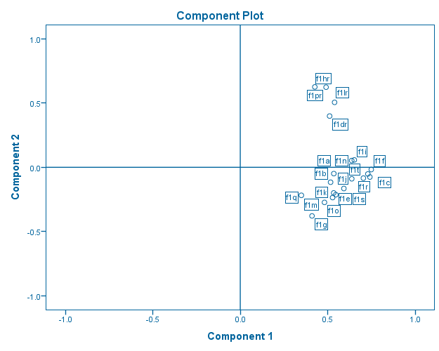

Factor Analysis  
Factor Analysis - Component Score Coefficient Matrix - November 19, 2017

Component Score Coefficient MatrixComponent Score Coefficient Matrix, table, 2 levels of column headers and 1 levels of row headers, table with 3 columns and 24 rows

|  | Component |  |
| --- | --- | --- |
|  | 1 | 2 |
| f1a CESD 1 - I was bothered by things that usually don't bother me | .081 | -.029 |
| f1b CESD 2 - I did not feel like eating; my appetite was poor | .078 | -.069 |
| f1c CESD 3 - I felt that I could not shake off the blues even with help from my family or friends | .110 | -.031 |
| f1e CESD 5 - I had trouble keeping my mind on what I was doing | .082 | -.128 |
| f1f CESD 6 - I felt depressed | .113 | -.011 |
| f1g CESD 7 - I felt that everything I did was an effort | .062 | -.226 |
| f1i CESD 9 - I thought my life had been a failure | .098 | .034 |
| f1j CESD 10 - I felt fearful | .096 | -.053 |
| f1k CESD 11 - My sleep was restless | .080 | -.119 |
| f1m CESD 13 - I talked less than usual | .053 | -.130 |
| f1n CESD 14 - I felt lonely | .096 | .031 |
| f1o CESD 15 - People were unfriendly | .073 | -.163 |
| f1q CESD 17 - I had crying spells | .080 | -.141 |
| f1r CESD 18 - I felt sad | .112 | -.045 |
| f1s CESD 19 - I felt that people dislike me | .089 | -.099 |
| f1t CESD 20 - I could not get going | .106 | -.050 |
| f1dr Reverse Coded CESD 4 - I felt that I was just as good as other people | .077 | .238 |
| f1hr Reverse Coded CESD 8 - I felt hopeful about the future | .064 | .373 |
| f1lr Reverse Coded CESD 12 - I was happy | .081 | .302 |
| f1pr Reverse Coded CESD 16 - I enjoyed life | .074 | .372 |

Extraction Method: Principal Component Analysis.

Factor Analysis  
Factor Analysis - Component Score Covariance Matrix - November 19, 2017

Component Score Covariance MatrixComponent Score Covariance Matrix, table, 1 levels of column headers and 1 levels of row headers, table with 3 columns and 5 rows

| Component | 1 | 2 |
| --- | --- | --- |
| 1 | 1.000 | .000 |
| 2 | .000 | 1.000 |

Extraction Method: Principal Component Analysis.

Log  
Log - Log - November 19, 2017

* you want the KMO stat close to 1  
* bartlett's test for sphericity should be significant  
* ideally the 1st eigenvalue should be much higher  
* than all the others - IF there is only ONE main factor  
* i.e. no subscales or multiple factors involved.  
* ideally no other eigenvalues should be > 1, but the change  
* between eigenvalue 1 and the rest is important  
* look at the component matrix - these are the loadings  
* and look at the Score Plot.  
* ideally no other eigenvalues should be > 1, but the change  
* between eigenvalue 1 and the rest is important  
* look at the component matrix - these are the loadings  
* and look at the Score Plot  
* ideally all of the items should cluster together.

[output not shown]

[output not shown]

[output not shown]

[output not shown]

[output not shown]

[output not shown]